# Análise Sensorial Hedônica – Projeto MostrAqui

Produtos Derivados do Pescado | UFOPA – Campus Monte Alegre

Autor do relatório: Dr. Carlos Antônio Zarzar

07 de junho de 2026

# 1 Pacotes e Configuração

```r
# Instale os pacotes caso necessário:
# install.packages(c("readxl","dplyr","tidyr","ggplot2","scales",
#                    "ggpubr","rstatix","corrplot","RColorBrewer",
#                    "patchwork","psych","MASS","tibble","stringr"))

suppressPackageStartupMessages({
  library(readxl)
  library(dplyr)
  library(tidyr)
  library(ggplot2)
  library(scales)
  library(ggpubr)
  library(rstatix)
  library(corrplot)
  library(RColorBrewer)
  library(patchwork)
  library(psych)
  library(MASS)      # polr() – regressão ordinal
  library(tibble)
  library(stringr)
})

set.seed(42)
```

> **Por que esses pacotes?**  
> O conjunto utilizado cobre toda a pipeline analítica: `readxl` lê dados do Excel; `dplyr`/`tidyr` fazem a limpeza e transformação; `ggplot2` + `ggpubr` + `patchwork` geram as figuras; `rstatix` executa testes não-paramétricos de forma *tidy*; `psych` fornece estatísticas descritivas ampliadas; `MASS` ajusta a regressão ordinal; e `corrplot` visualiza correlações.

# 2 Leitura e Limpeza dos Dados

```r
df_raw <- read_excel("df_mostraqui.xlsx")

# Padroniza nomes (remove espaços, acentos problemáticos)
names(df_raw) <- c("id","entrevistado","grupo","sexo","idade",
                   "amostra","cor","aroma","aparencia","sabor",
                   "impressao","compra","derivados","vezes")

# Converte colunas de pontuação para numérico
df_raw <- df_raw %>%
  dplyr::mutate(across(c(cor, aroma, aparencia, sabor, impressao, compra, vezes),
                       as.numeric))
```

```r
df <- df_raw %>%
  mutate(
    amostra = str_trim(amostra),

    sexo = case_when(
      toupper(str_trim(sexo)) %in% c("F","FEMININO")  ~ "Feminino",
      toupper(str_trim(sexo)) %in% c("M","MASCULINO") ~ "Masculino",
      TRUE                                              ~ NA_character_
    ),

    idade = suppressWarnings(as.numeric(as.character(idade))),

    derivados = case_when(
      toupper(str_trim(derivados)) == "SIM" ~ "Sim",
      toupper(str_trim(derivados)) %in% c("NÃO","NAO","NÃO","NAO","NAOO") ~ "Não",
      TRUE ~ NA_character_
    ),

    faixa_etaria = cut(idade,
                       breaks = c(0, 17, 29, 44, 59, Inf),
                       labels = c("≤17 anos","18–29","30–44","45–59","≥60"),
                       right  = TRUE, include.lowest = TRUE),

    grupo_label = case_when(
      grupo == 2 ~ "Grupo 2\n(Lasanha / Coxinha / Arroz)",
      grupo == 3 ~ "Grupo 3\n(Patê / Farofa / Empada)",
      grupo == 4 ~ "Grupo 4\n(Risole / Hot Fish / Fishburguer)",
      grupo == 5 ~ "Grupo 5\n(Iscas / Brigadeiro)",
      TRUE       ~ paste("Grupo", grupo)
    ),

    hedonico_medio = rowMeans(
      dplyr::select(., cor, aroma, aparencia, sabor, impressao), na.rm = TRUE),

    compra_ord = factor(compra, levels = 1:5,
                        labels = c("Certamente\nnão compraria",
                                   "Possivelmente\nnão compraria",
                                   "Talvez comprasse /\ntalvez não",
                                   "Possivelmente\ncompraria",
                                   "Certamente\ncompraria"),
                        ordered = TRUE),

    aceito = impressao >= 4
  )

# Abreviações para gráficos
abrev_produtos <- c(
  "Arroz Paraense com Polvo"                              = "Arroz c/ Polvo",
  "Brigadeiro de Coco com Pescada"                        = "Brigadeiro c/ Pescada",
  "Coxinha de Rã com creme de queijo regional"            = "Coxinha de Rã",
  "Empada de Tamoatá com creme de queijo regional"        = "Empada de Tamoatá",
  "Farofa de Tambaqui com Banana"                         = "Farofa c/ Banana",
  "Fishburguer de Acari"                                  = "Fishburguer (Acari)",
  "Hot Fish de Tambaqui"                                  = "Hot Fish (Tambaqui)",
  "Isca de Pirapitinga com Doce de Castanha de Caju e Mel"= "Isca (Pirapitinga)",
  "Isca de Pirarucu com Geleia de Cupuaçu Picante"        = "Isca (Pirarucu)",
  "Lasanha de Tucunaré"                                   = "Lasanha (Tucunaré)",
  "Patê de Pirarucu"                                      = "Patê de Pirarucu",
  "Risole de Tambaqui"                                    = "Risole (Tambaqui)"
)

df <- df %>%
  mutate(produto_abrev = recode(amostra, !!!abrev_produtos))
```

## 2.1 Qualidade dos dados

### 2.1.1 Resumo Geral

```r
cat(sprintf("Avaliações totais:   %d\n", nrow(df)))
```

```
## Avaliações totais:   1154
```

```r
cat(sprintf("Avaliadores únicos:  %d (somando todos os grupos)\n",
            sum(sapply(unique(df$grupo),
                       function(g) n_distinct(df$entrevistado[df$grupo == g])))))
```

```
## Avaliadores únicos:  394 (somando todos os grupos)
```

```r
cat(sprintf("Produtos únicos:     %d\n", n_distinct(df$amostra)))
```

```
## Produtos únicos:     12
```

```r
cat(sprintf("Grupos temáticos:    %d\n", n_distinct(df$grupo)))
```

```
## Grupos temáticos:    4
```

### 2.1.2 Missings por Variável

```r
na_tab <- colSums(is.na(df[, c("sexo","idade","cor","aroma","aparencia",
                               "sabor","impressao","compra","derivados","vezes")]))
na_df <- data.frame(
  Variável = names(na_tab),
  N_missing = na_tab,
  Pct       = round(na_tab / nrow(df) * 100, 1),
  row.names = NULL
) %>% filter(N_missing > 0)

knitr::kable(na_df, col.names = c("Variável", "N ausentes", "%"),
             caption = "Dados ausentes por variável")
```

Dados ausentes por variável

| Variável | N ausentes | % |
| --- | --- | --- |
| sexo | 6 | 0.5 |
| idade | 39 | 3.4 |
| cor | 27 | 2.3 |
| aroma | 37 | 3.2 |
| aparencia | 31 | 2.7 |
| sabor | 32 | 2.8 |
| impressao | 33 | 2.9 |
| compra | 48 | 4.2 |
| derivados | 17 | 1.5 |
| vezes | 52 | 4.5 |

> **Interpretação Qualidade dos Dados:**  
> O banco contém **1.154 avaliações** de **394 avaliadores únicos** distribuídos em 4 grupos, cobrindo **12 produtos** distintos de origem pesqueira. Os dados ausentes são baixos (< 5% em todas as variáveis), o que não compromete as análises. A variável `vezes` (frequência de consumo) apresenta o maior percentual de ausência (4,5%), possivelmente por ser a última questão do formulário. Não há evidências de viés sistemático na ausência de dados.

# 3 Perfil dos Avaliadores

```r
perfil <- df %>%
  distinct(grupo, entrevistado, .keep_all = TRUE) %>%
  group_by(grupo) %>%
  summarise(
    N_total     = n(),
    Feminino    = sum(sexo == "Feminino",  na.rm = TRUE),
    Masculino   = sum(sexo == "Masculino", na.rm = TRUE),
    Pct_F       = round(Feminino / (Feminino + Masculino) * 100, 1),
    Idade_md    = round(median(idade, na.rm = TRUE), 0),
    Idade_med   = round(mean(idade, na.rm = TRUE), 1),
    Idade_dp    = round(sd(idade, na.rm = TRUE), 1),
    Consome_pct = round(mean(derivados == "Sim", na.rm = TRUE) * 100, 1),
    .groups = "drop")

knitr::kable(perfil,
             col.names = c("Grupo","N Total","Feminino","Masculino",
                           "% Fem.","Mediana Idade","Média Idade","DP Idade",
                           "% Consome Derivados"),
             caption = "Perfil dos avaliadores por grupo")
```

Perfil dos avaliadores por grupo

| Grupo | N Total | Feminino | Masculino | % Fem. | Mediana Idade | Média Idade | DP Idade | % Consome Derivados |
| --- | --- | --- | --- | --- | --- | --- | --- | --- |
| 2 | 97 | 61 | 34 | 64.2 | 26 | 30.7 | 13.2 | 99.0 |
| 3 | 100 | 61 | 39 | 61.0 | 30 | 31.2 | 12.3 | 98.0 |
| 4 | 97 | 59 | 38 | 60.8 | 30 | 31.3 | 13.4 | 99.0 |
| 5 | 100 | 64 | 36 | 64.0 | 32 | 32.3 | 14.1 | 94.9 |

```r
idade_geral <- df %>%
  distinct(grupo, entrevistado, .keep_all = TRUE) %>%
  summarise(med   = median(idade, na.rm = TRUE),
            media = mean(idade,   na.rm = TRUE),
            dp    = sd(idade,     na.rm = TRUE))

cat(sprintf("Idade geral:  mediana = %g anos  |  média = %.1f anos  |  DP = %.1f anos\n",
            idade_geral$med, idade_geral$media, idade_geral$dp))
```

```
## Idade geral:  mediana = 30 anos  |  média = 31.4 anos  |  DP = 13.2 anos
```

> **Interpretação Perfil dos Avaliadores:**  
> O painel sensorial foi composto por **394 avaliadores**, com predominância do público **feminino** (≈ 61–64% em todos os grupos), faixa etária concentrada em adultos jovens (mediana entre 26 e 32 anos; DP ≈ 13 anos) e elevado nível de familiaridade com produtos derivados de pescado (≥ 94,9% relataram consumo habitual). Esse perfil demográfico e de consumo é compatível com o público-alvo da Feira MostrAqui, reforçando a representatividade amostral e a validade externa do estudo, uma vez que os participantes correspondem a consumidores potenciais e reais do produto na região. Além disso, a relativa homogeneidade entre os grupos avaliados contribui para maior robustez das comparações diretas realizadas entre os tratamentos.

# 4 Estatísticas Descritivas dos Atributos

```r
attrs <- c("cor","aroma","aparencia","sabor","impressao","compra")
desc <- df %>%
  dplyr::select(all_of(attrs)) %>%
  psych::describe() %>%
  dplyr::select(n, mean, sd, median, min, max, skew, kurtosis)

knitr::kable(round(desc, 3),
             col.names = c("N","Média","DP","Mediana","Mín","Máx","Assimetria","Curtose"),
             caption = "Estatísticas descritivas – todos os produtos e grupos")
```

Estatísticas descritivas – todos os produtos e grupos

|  | N | Média | DP | Mediana | Mín | Máx | Assimetria | Curtose |
| --- | --- | --- | --- | --- | --- | --- | --- | --- |
| cor | 1127 | 4.255 | 0.966 | 5 | 1 | 5 | -1.395 | 1.560 |
| aroma | 1117 | 4.193 | 0.963 | 4 | 1 | 5 | -1.206 | 0.961 |
| aparencia | 1123 | 4.297 | 0.891 | 5 | 1 | 5 | -1.395 | 1.803 |
| sabor | 1122 | 4.168 | 1.049 | 5 | 1 | 5 | -1.225 | 0.746 |
| impressao | 1121 | 4.194 | 0.972 | 4 | 1 | 5 | -1.232 | 1.044 |
| compra | 1106 | 4.103 | 1.256 | 5 | 1 | 5 | -1.296 | 0.528 |

> **Interpretação Estatísticas Descritivas Gerais:**  
> Todos os atributos sensoriais apresentaram **médias acima de 4,1** (escala de 1–5), indicando aceitação geral elevada dos produtos. A **aparência** obteve a maior média (4,297), sugerindo que a apresentação visual dos produtos foi particularmente bem recebida. Os valores de **assimetria negativa** (entre −1,2 e −1,4) em todos os atributos indicam que as notas se concentram no extremo superior da escala padrão esperado em análises hedônicas de produtos com boa aceitação. A **curtose positiva** (especialmente em `cor` = 1,56 e `aparencia` = 1,80) revela distribuições leptocúrticas, com muitas avaliações próximas ao valor máximo (5). Em conjunto, esses resultados evidenciam elevada aceitação sensorial do cardápio avaliado, indicando que os produtos apresentaram desempenho satisfatório junto ao público consumidor.

## 4.1 Médias por Produto e Atributo

```r
resumo_prod <- df %>%
  group_by(grupo, amostra, produto_abrev) %>%
  summarise(
    N         = sum(!is.na(impressao)),
    Cor       = round(mean(cor,        na.rm = TRUE), 2),
    Aroma     = round(mean(aroma,      na.rm = TRUE), 2),
    Aparencia = round(mean(aparencia,  na.rm = TRUE), 2),
    Sabor     = round(mean(sabor,      na.rm = TRUE), 2),
    Impressao = round(mean(impressao,  na.rm = TRUE), 2),
    Compra    = round(mean(compra,     na.rm = TRUE), 2),
    Hedonico  = round(mean(hedonico_medio, na.rm = TRUE), 2),
    Aceit_pct = round(mean(aceito, na.rm = TRUE) * 100, 1),
    DP_imp    = round(sd(impressao, na.rm = TRUE), 2),
    .groups   = "drop"
  ) %>%
  arrange(grupo, desc(Impressao))

knitr::kable(
  resumo_prod %>% dplyr::select(-amostra),
  col.names = c("Grupo","Produto","N","Cor","Aroma","Aparência",
                "Sabor","Impressão","Compra","Hedônico","Aceit. %","DP"),
  caption   = "Médias hedônicas por produto e atributo"
)
```

Médias hedônicas por produto e atributo

| Grupo | Produto | N | Cor | Aroma | Aparência | Sabor | Impressão | Compra | Hedônico | Aceit. % | DP |
| --- | --- | --- | --- | --- | --- | --- | --- | --- | --- | --- | --- |
| 2 | Coxinha de Rã | 90 | 4.67 | 4.62 | 4.71 | 4.60 | 4.64 | 4.49 | 4.66 | 95.6 | 0.61 |
| 2 | Lasanha (Tucunaré) | 90 | 4.12 | 4.07 | 4.25 | 4.10 | 4.14 | 3.91 | 4.13 | 80.0 | 0.98 |
| 2 | Arroz c/ Polvo | 85 | 3.87 | 3.82 | 4.08 | 3.65 | 3.81 | 3.36 | 3.85 | 63.5 | 1.16 |
| 3 | Patê de Pirarucu | 100 | 4.68 | 4.56 | 4.64 | 4.70 | 4.61 | 4.71 | 4.64 | 97.0 | 0.58 |
| 3 | Empada de Tamoatá | 94 | 4.36 | 4.35 | 4.43 | 4.36 | 4.36 | 4.36 | 4.37 | 87.2 | 0.81 |
| 3 | Farofa c/ Banana | 100 | 3.90 | 3.95 | 3.98 | 3.79 | 3.85 | 3.78 | 3.89 | 67.0 | 0.97 |
| 4 | Fishburguer (Acari) | 85 | 4.72 | 4.59 | 4.64 | 4.59 | 4.54 | 4.65 | 4.61 | 94.1 | 0.65 |
| 4 | Risole (Tambaqui) | 97 | 4.40 | 4.33 | 4.43 | 4.33 | 4.35 | 4.31 | 4.37 | 87.6 | 0.75 |
| 4 | Hot Fish (Tambaqui) | 92 | 4.14 | 4.11 | 4.24 | 3.97 | 4.07 | 3.89 | 4.10 | 77.2 | 0.89 |
| 5 | Isca (Pirarucu) | 99 | 4.45 | 4.35 | 4.42 | 4.47 | 4.43 | 4.36 | 4.43 | 90.9 | 0.87 |
| 5 | Brigadeiro c/ Pescada | 98 | 4.20 | 4.12 | 4.31 | 4.15 | 4.13 | 4.15 | 4.18 | 77.6 | 0.96 |
| 5 | Isca (Pirapitinga) | 91 | 3.52 | 3.41 | 3.42 | 3.26 | 3.34 | 3.21 | 3.38 | 51.6 | 1.36 |

> **Interpretação Médias por Produto:**  
> **Coxinha de Rã** (Grupo 2), **Patê de Pirarucu** (Grupo 3) e **Fishburguer de Acari** (Grupo 4) destacam-se com as maiores notas de impressão global (≥ 4,54) e **média hedônica** (≥ 4,61), classificando-se como os produtos de maior aceitação do evento. Em contraste, a **Isca de Pirapitinga** (Grupo 5) obteve as menores médias em todos os atributos (Impressão = 3,34; Hedônico = 3,38), sinalizando necessidade de reformulação da receita. O **Desvio-Padrão (DP) da impressão** é um indicador de consenso: valores baixos (< 0,70) como os da Coxinha de Rã e do Patê de Pirarucu indicam que praticamente todos os avaliadores concordaram positivamente, enquanto o DP de 1,36 da Isca de Pirapitinga revela alta divergência de opiniões.

**Nota:** Entende-se por média hedônica a média aritmética das notas aos atributos sensoriais avaliados de cada produto (cor, aroma, aparência, sabor e impressão global). O termo hedônico refere-se à percepção de prazer, satisfação ou aceitação do consumidor em relação ao produto analisado.

# 5 Índice de Aceitabilidade (IA%)

O Índice de Aceitabilidade é calculado como:

$$IA\% = \frac{\bar{x}}{x_{max}} \times
100$$

onde $\bar{x}$ é a média das notas e $x_{max} = 5$ (nota máxima da escala). **Produtos com IA ≥ 70% são considerados aceitos**.

```r
ia_tab <- resumo_prod %>%
  mutate(
    IA_impressao = round(Impressao / 5 * 100, 1),
    IA_sabor     = round(Sabor / 5 * 100, 1),
    Aceito       = ifelse(IA_impressao >= 70, "✓ Aprovado", "✗ Reprovado")
  ) %>%
  dplyr::select(grupo, produto_abrev, N, IA_impressao, IA_sabor, Aceit_pct, Aceito) %>%
  arrange(desc(IA_impressao))

knitr::kable(ia_tab,
             col.names = c("Grupo","Produto","N","IA Impressão (%)","IA Sabor (%)",
                           "% Avaliadores (nota ≥4)","Status"),
             caption = "Índice de Aceitabilidade por produto")
```

Índice de Aceitabilidade por produto

| Grupo | Produto | N | IA Impressão (%) | IA Sabor (%) | % Avaliadores (nota ≥4) | Status |
| --- | --- | --- | --- | --- | --- | --- |
| 2 | Coxinha de Rã | 90 | 92.8 | 92.0 | 95.6 | ✓ Aprovado |
| 3 | Patê de Pirarucu | 100 | 92.2 | 94.0 | 97.0 | ✓ Aprovado |
| 4 | Fishburguer (Acari) | 85 | 90.8 | 91.8 | 94.1 | ✓ Aprovado |
| 5 | Isca (Pirarucu) | 99 | 88.6 | 89.4 | 90.9 | ✓ Aprovado |
| 3 | Empada de Tamoatá | 94 | 87.2 | 87.2 | 87.2 | ✓ Aprovado |
| 4 | Risole (Tambaqui) | 97 | 87.0 | 86.6 | 87.6 | ✓ Aprovado |
| 2 | Lasanha (Tucunaré) | 90 | 82.8 | 82.0 | 80.0 | ✓ Aprovado |
| 5 | Brigadeiro c/ Pescada | 98 | 82.6 | 83.0 | 77.6 | ✓ Aprovado |
| 4 | Hot Fish (Tambaqui) | 92 | 81.4 | 79.4 | 77.2 | ✓ Aprovado |
| 3 | Farofa c/ Banana | 100 | 77.0 | 75.8 | 67.0 | ✓ Aprovado |
| 2 | Arroz c/ Polvo | 85 | 76.2 | 73.0 | 63.5 | ✓ Aprovado |
| 5 | Isca (Pirapitinga) | 91 | 66.8 | 65.2 | 51.6 | ✗ Reprovado |

```r
cat(sprintf("Produtos aprovados (IA ≥ 70%%): %d de %d\n",
            sum(ia_tab$Aceito == "✓ Aprovado"), nrow(ia_tab)))
```

```
## Produtos aprovados (IA ≥ 70%): 11 de 12
```

> **Interpretação Índice de Aceitabilidade:**  
> **11 dos 12 produtos** (91,7%) atingiram o limiar mínimo de aceitabilidade de 70%, demonstrando o êxito geral das formulações apresentadas na Feira MostrAqui. O destaque vai para **Patê de Pirarucu** (IA = 92,2%), **Coxinha de Rã** (IA = 92,8%) e **Fishburguer de Acari** (IA = 90,8%), todos acima de 90%. A **Isca de Pirapitinga** foi o único produto reprovado (IA = 66,8%), possivelmente em decorrência da combinação pouco convencional entre peixe, doce de castanha-de-caju e mel, a qual pode ter influenciado a percepção sensorial e a aceitabilidade do produto pelo público consumidor. Vale notar que o **IA do Sabor** da Isca de Pirapitinga (65,2%) é ainda menor que o IA da Impressão, sugerindo que é justamente o perfil gustativo o principal ponto fraco do produto.

# 6 Intenção de Compra

```r
compra_tab <- df %>%
  filter(!is.na(compra)) %>%
  group_by(produto_abrev) %>%
  summarise(
    N            = n(),
    Media        = round(mean(compra), 2),
    DP           = round(sd(compra), 2),
    Mediana      = median(compra),
    Pct_positiva = round(mean(compra >= 4) * 100, 1), # Possivelmente+Certamente - Calcula o percentual de respostas positivas.
    .groups = "drop"
  ) %>%
  arrange(desc(Media))

knitr::kable(compra_tab,
             col.names = c("Produto","N","Média","DP","Mediana","% Intenção Positiva (≥4)"),
             caption   = "Intenção de compra por produto (escala 1–5)")
```

Intenção de compra por produto (escala 1–5)

| Produto | N | Média | DP | Mediana | % Intenção Positiva (≥4) |
| --- | --- | --- | --- | --- | --- |
| Patê de Pirarucu | 97 | 4.71 | 0.59 | 5 | 94.8 |
| Fishburguer (Acari) | 85 | 4.65 | 0.72 | 5 | 94.1 |
| Coxinha de Rã | 89 | 4.49 | 1.01 | 5 | 86.5 |
| Empada de Tamoatá | 94 | 4.36 | 1.11 | 5 | 80.9 |
| Isca (Pirarucu) | 91 | 4.36 | 1.08 | 5 | 85.7 |
| Risole (Tambaqui) | 97 | 4.31 | 0.97 | 5 | 83.5 |
| Brigadeiro c/ Pescada | 98 | 4.15 | 1.17 | 5 | 74.5 |
| Lasanha (Tucunaré) | 87 | 3.91 | 1.30 | 4 | 66.7 |
| Hot Fish (Tambaqui) | 92 | 3.89 | 1.18 | 4 | 69.6 |
| Farofa c/ Banana | 100 | 3.78 | 1.39 | 4 | 63.0 |
| Arroz c/ Polvo | 85 | 3.36 | 1.60 | 4 | 54.1 |
| Isca (Pirapitinga) | 91 | 3.21 | 1.58 | 3 | 48.4 |

> **Interpretação Intenção de Compra:**  
> A intenção de compra apresentou comportamento consistente com os resultados de aceitação hedônica observados para os produtos avaliados. **O Patê de Pirarucu** destacou-se com a maior média de intenção de compra (4,71) e elevada proporção de respostas positivas (94,8%), seguido pelo **Fishburguer de Acari** (4,65; 94,1%), indicando elevado potencial de aceitação mercadológica e comercialização. Em contrapartida, o **Arroz com Polvo** apresentou a maior dispersão das respostas (DP = 1,60) e menor percentual de intenção positiva entre os produtos aprovados (54,1%), sugerindo maior heterogeneidade na percepção dos consumidores e indicando necessidade de ajustes na formulação ou apresentação do produto. A **Isca de Pirapitinga** apresentou os menores índices de intenção positiva (48,4%), resultado que reforça sua menor aceitação comercial em relação aos demais produtos avaliados. De forma geral, produtos com médias de intenção de compra iguais ou superiores a 4,3 demonstraram elevado potencial de inserção e aceitação no mercado consumidor.

# 7 Médias Hedônicas por Grupo

```r
resumo_grupo <- df %>%
  group_by(grupo) %>%
  summarise(across(c(cor, aroma, aparencia, sabor, impressao, compra),
                   list(med = ~round(mean(.x, na.rm = TRUE), 2)),
                   .names = "{.col}"),
            Aceit_pct = round(mean(aceito, na.rm = TRUE) * 100, 1),
            N_aval    = sum(!is.na(impressao)),
            .groups   = "drop")
knitr::kable(resumo_grupo,
             col.names = c("Grupo","Cor","Aroma","Aparência",
                           "Sabor","Impressão","Compra","% Aceitos","N Aval."),
             caption   = "Médias hedônicas e aceitabilidade por grupo temático")
```

Médias hedônicas e aceitabilidade por grupo temático

| Grupo | Cor | Aroma | Aparência | Sabor | Impressão | Compra | % Aceitos | N Aval. |
| --- | --- | --- | --- | --- | --- | --- | --- | --- |
| 2 | 4.23 | 4.18 | 4.35 | 4.12 | 4.21 | 3.93 | 80.0 | 1 |
| 3 | 4.31 | 4.28 | 4.35 | 4.28 | 4.27 | 4.28 | 83.7 | 1 |
| 4 | 4.41 | 4.34 | 4.43 | 4.29 | 4.31 | 4.27 | 86.1 | 1 |
| 5 | 4.07 | 3.98 | 4.07 | 3.98 | 3.99 | 3.91 | 74.0 | 1 |

> **Interpretação Comparação entre Grupos:**  
> O **Grupo 4** (Risole / Hot Fish / Fishburguer) obteve as maiores médias em cor (4,41), aparência (4,43) e impressão (4,31), sendo o grupo com melhor desempenho hedônico geral (86,1% de aceitação). O **Grupo 3** (Patê / Farofa / Empada) se destacou na intenção de compra média (4,28). O **Grupo 5** (Iscas / Brigadeiro) apresentou os resultados mais baixos (impressão = 3,99; 74% de aceitação), puxados para baixo pela Isca de Pirapitinga. Essa heterogeneidade interna ao Grupo 5 é importante: o Brigadeiro c/ Pescada e a Isca de Pirarucu têm desempenhos satisfatórios, enquanto a Isca de Pirapitinga compromete a média grupal. Essa análise por grupo deve ser interpretada com cautela quando há produtos com desempenhos muito discrepantes dentro do mesmo grupo.

# 8 Análise Inferencial

> **Por que testes não-paramétricos?**  
> Os dados hedônicos são mensurados em **escala ordinal** (1–5) e as distribuições apresentam assimetria negativa (conforme visto nas descritivas), violando os pressupostos de normalidade dos testes paramétricos clássicos (ANOVA). O **teste de Kruskal-Wallis** é o equivalente não-paramétrico da ANOVA de um fator, testando se pelo menos um grupo difere dos demais. O **teste post-hoc de Dunn** com correção de Bonferroni identifica *quais* pares de produtos diferem entre si. O **teste de Wilcoxon** compara dois grupos independentes.

## 8.1 Kruskal-Wallis entre produtos

```r
cat("─ Kruskal-Wallis: Impressão Global entre produtos ─\n")
```

```
## ─ Kruskal-Wallis: Impressão Global entre produtos ─
```

```r
kw_prod <- kruskal.test(impressao ~ amostra, data = df)
print(kw_prod)
```

```
##
##  Kruskal-Wallis rank sum test
##
## data:  impressao by amostra
## Kruskal-Wallis chi-squared = 133.4, df = 11, p-value < 2.2e-16
```

```r
if (kw_prod$p.value < 0.05) {
  cat("  → Diferença significativa (p < 0.05). Pós-teste de Dunn (Bonferroni):\n")
  dunn_res <- df %>%
    filter(!is.na(impressao)) %>%
    dunn_test(impressao ~ amostra, p.adjust.method = "bonferroni") %>%
    filter(p.adj < 0.05) %>%
    arrange(p.adj)
  cat(sprintf("  Pares significativos: %d\n", nrow(dunn_res)))
  if (nrow(dunn_res) > 0) {
    knitr::kable(
      dunn_res %>%
        dplyr::select(group1, group2, statistic, p.adj) %>%
        mutate(across(where(is.numeric), ~round(.x, 4))),
      col.names = c("Grupo 1","Grupo 2","Estatística","p.adj (Bonferroni)"),
      caption   = "Pares com diferença significativa – Dunn post-hoc"
    )
  }
}
```

```
##   → Diferença significativa (p < 0.05). Pós-teste de Dunn (Bonferroni):
##   Pares significativos: 24
```

Pares com diferença significativa – Dunn post-hoc

| Grupo 1 | Grupo 2 | Estatística | p.adj (Bonferroni) |
| --- | --- | --- | --- |
| Coxinha de Rã com creme de queijo regional | Isca de Pirapitinga com Doce de Castanha de Caju e Mel | -7.8646 | 0.0000 |
| Isca de Pirapitinga com Doce de Castanha de Caju e Mel | Patê de Pirarucu | 7.6329 | 0.0000 |
| Fishburguer de Acari | Isca de Pirapitinga com Doce de Castanha de Caju e Mel | -6.7823 | 0.0000 |
| Isca de Pirapitinga com Doce de Castanha de Caju e Mel | Isca de Pirarucu com Geleia de Cupuaçu Picante | 6.5881 | 0.0000 |
| Coxinha de Rã com creme de queijo regional | Farofa de Tambaqui com Banana | -6.1504 | 0.0000 |
| Farofa de Tambaqui com Banana | Patê de Pirarucu | 5.8709 | 0.0000 |
| Empada de Tamoatá com creme de queijo regional | Isca de Pirapitinga com Doce de Castanha de Caju e Mel | -5.6723 | 0.0000 |
| Arroz Paraense com Polvo | Coxinha de Rã com creme de queijo regional | 5.4767 | 0.0000 |
| Isca de Pirapitinga com Doce de Castanha de Caju e Mel | Risole de Tambaqui | 5.4022 | 0.0000 |
| Arroz Paraense com Polvo | Patê de Pirarucu | 5.1854 | 0.0000 |
| Farofa de Tambaqui com Banana | Fishburguer de Acari | 5.0669 | 0.0000 |
| Farofa de Tambaqui com Banana | Isca de Pirarucu com Geleia de Cupuaçu Picante | 4.8048 | 0.0001 |
| Coxinha de Rã com creme de queijo regional | Hot Fish de Tambaqui | -4.6507 | 0.0002 |
| Arroz Paraense com Polvo | Fishburguer de Acari | 4.4476 | 0.0006 |
| Hot Fish de Tambaqui | Patê de Pirarucu | 4.3344 | 0.0010 |
| Isca de Pirapitinga com Doce de Castanha de Caju e Mel | Lasanha de Tucunaré | 4.1988 | 0.0018 |
| Arroz Paraense com Polvo | Isca de Pirarucu com Geleia de Cupuaçu Picante | 4.1653 | 0.0021 |
| Brigadeiro de Coco com Pescada | Isca de Pirapitinga com Doce de Castanha de Caju e Mel | -4.1272 | 0.0024 |
| Brigadeiro de Coco com Pescada | Coxinha de Rã com creme de queijo regional | 3.8928 | 0.0065 |
| Empada de Tamoatá com creme de queijo regional | Farofa de Tambaqui com Banana | -3.8886 | 0.0067 |
| Coxinha de Rã com creme de queijo regional | Lasanha de Tucunaré | -3.6558 | 0.0169 |
| Fishburguer de Acari | Hot Fish de Tambaqui | -3.6119 | 0.0201 |
| Farofa de Tambaqui com Banana | Risole de Tambaqui | 3.5987 | 0.0211 |
| Brigadeiro de Coco com Pescada | Patê de Pirarucu | 3.5527 | 0.0252 |

> **Como interpretar:** Se **p < 0,05** no Kruskal-Wallis, ao menos um produto difere dos demais. Os pares listados no Dunn (p.adj < 0,05) são aqueles com diferença **estatisticamente significativa** após correção para comparações múltiplas. Valores de estatística mais altos (em módulo) indicam maior afastamento entre os postos médios dos dois grupos comparados.

## 8.2 Kruskal-Wallis entre grupos temáticos

```r
cat("─ Kruskal-Wallis: Impressão Global entre grupos temáticos ─\n")
```

```
## ─ Kruskal-Wallis: Impressão Global entre grupos temáticos ─
```

```r
kw_grupo <- kruskal.test(impressao ~ grupo, data = df)
print(kw_grupo)
```

```
##
##  Kruskal-Wallis rank sum test
##
## data:  impressao by grupo
## Kruskal-Wallis chi-squared = 9.1431, df = 3, p-value = 0.02745
```

> **Como interpretar:** Este teste verifica se os 4 grupos temáticos (Grupo 2–5) diferem entre si na impressão global. Um resultado significativo (p < 0,05) indica que a composição dos produtos dentro de cada grupo influi no desempenho hedônico médio do conjunto.

## 8.3 Kruskal-Wallis por atributo

```r
cat("─ Kruskal-Wallis por atributo entre produtos ─\n\n")
```

```
## ─ Kruskal-Wallis por atributo entre produtos ─
```

```r
kw_tab <- data.frame(
  Atributo   = character(),
  H          = numeric(),
  gl         = numeric(),
  p_valor    = numeric(),
  Sig        = character(),
  stringsAsFactors = FALSE
)

for (a in c("cor","aroma","aparencia","sabor","impressao","compra")) {
  kw_a <- kruskal.test(as.formula(paste(a, "~ amostra")), data = df)
  sig  <- ifelse(kw_a$p.value < 0.001, "***",
           ifelse(kw_a$p.value < 0.01,  "**",
           ifelse(kw_a$p.value < 0.05,  "*", "ns")))
  kw_tab <- rbind(kw_tab, data.frame(
    Atributo = a,
    H        = round(kw_a$statistic, 2),
    gl       = kw_a$parameter,
    p_valor  = round(kw_a$p.value, 4),
    Sig      = sig
  ))
}

knitr::kable(kw_tab,
             col.names = c("Atributo","H","gl","p-valor","Sig."),
             caption   = "Kruskal-Wallis por atributo sensorial entre produtos")
```

Kruskal-Wallis por atributo sensorial entre produtos

|  | Atributo | H | gl | p-valor | Sig. |
| --- | --- | --- | --- | --- | --- |
| Kruskal-Wallis chi-squared | cor | 131.57 | 11 | 0 | *** |
| Kruskal-Wallis chi-squared1 | aroma | 107.14 | 11 | 0 | *** |
| Kruskal-Wallis chi-squared2 | aparencia | 113.95 | 11 | 0 | *** |
| Kruskal-Wallis chi-squared3 | sabor | 150.53 | 11 | 0 | *** |
| Kruskal-Wallis chi-squared4 | impressao | 133.40 | 11 | 0 | *** |
| Kruskal-Wallis chi-squared5 | compra | 128.86 | 11 | 0 | *** |

> **Legenda de significância:** `***` p < 0,001 | `**` p < 0,01 | `*` p < 0,05 | `ns` não significativo.  
> Atributos com H elevado e p < 0,001 apresentam grande variabilidade entre produtos ou seja, os produtos se diferenciam claramente nesse atributo, sendo candidatos a análises post-hoc mais detalhadas.

## 8.4 Wilcoxon: Impressão Global por Sexo

```r
df_sx <- df %>% filter(sexo %in% c("Feminino","Masculino"), !is.na(impressao))
wt    <- wilcox.test(impressao ~ sexo, data = df_sx)

cat(sprintf("W = %.0f  |  p = %.4f  %s\n",
            wt$statistic, wt$p.value,
            ifelse(wt$p.value < 0.05,
                   "(diferença significativa entre sexos)",
                   "(sem diferença significativa entre sexos)")))
```

```
## W = 141242  |  p = 0.3208  (sem diferença significativa entre sexos)
```

```r
med_sx <- df_sx %>%
  group_by(sexo) %>%
  summarise(Mediana = median(impressao),
            Média   = round(mean(impressao), 2),
            .groups = "drop")

knitr::kable(med_sx, caption = "Impressão Global por sexo")
```

Impressão Global por sexo

| sexo | Mediana | Média |
| --- | --- | --- |
| Feminino | 4 | 4.17 |
| Masculino | 4 | 4.23 |

> **Como interpretar:** O teste de Wilcoxon compara as distribuições de notas entre homens e mulheres. Se p ≥ 0,05, não há evidência estatística de que os dois sexos avaliam os produtos de forma diferente o que fortalece a representatividade geral do painel.

## 8.5 Correlação Spearman: Idade × Impressão

```r
cor_idade <- cor.test(df$idade, df$impressao, method = "spearman", exact = FALSE)
cat(sprintf("ρ de Spearman (Idade × Impressão Global): ρ = %.3f  |  p = %.4f\n",
            cor_idade$estimate, cor_idade$p.value))
```

```
## ρ de Spearman (Idade × Impressão Global): ρ = 0.026  |  p = 0.3851
```

> **Como interpretar:** Um ρ próximo de zero indica que a idade dos avaliadores não está associada à aceitação hedônica, ou seja, o produto agrada (ou desagrada) de forma semelhante em diferentes faixas etárias. Se ρ for significativo e negativo, avaliadores mais velhos tendem a dar notas mais baixas; se positivo, o oposto. Nesse caso não foi significativo.

# 9 Correlações de Spearman

```r
cat("▶ MATRIZ DE CORRELAÇÕES SPEARMAN (atributos + compra)\n\n")
```

```
## ▶ MATRIZ DE CORRELAÇÕES SPEARMAN (atributos + compra)
```

```r
cor_mat <- df %>%
  dplyr::select(cor, aroma, aparencia, sabor, impressao, compra) %>%
  cor(method = "spearman", use = "pairwise.complete.obs")

knitr::kable(round(cor_mat, 3),
             caption = "Matriz de correlações de Spearman entre atributos sensoriais")
```

Matriz de correlações de Spearman entre atributos sensoriais

|  | cor | aroma | aparencia | sabor | impressao | compra |
| --- | --- | --- | --- | --- | --- | --- |
| cor | 1.000 | 0.785 | 0.748 | 0.789 | 0.779 | 0.724 |
| aroma | 0.785 | 1.000 | 0.763 | 0.779 | 0.821 | 0.712 |
| aparencia | 0.748 | 0.763 | 1.000 | 0.745 | 0.797 | 0.674 |
| sabor | 0.789 | 0.779 | 0.745 | 1.000 | 0.860 | 0.795 |
| impressao | 0.779 | 0.821 | 0.797 | 0.860 | 1.000 | 0.771 |
| compra | 0.724 | 0.712 | 0.674 | 0.795 | 0.771 | 1.000 |

```r
cor_ic <- cor.test(df$impressao, df$compra, method = "spearman", exact = FALSE)
cat(sprintf("\nImpressão Global × Intenção de Compra: ρ = %.3f  p < 0.001\n",
            cor_ic$estimate))
```

```
##
## Impressão Global × Intenção de Compra: ρ = 0.771  p < 0.001
```

> **Como interpretar as Correlações de Spearman:**  
> O coeficiente ρ (rho) varia de −1 a +1. Valores próximos de **+1** indicam forte associação positiva: avaliadores que deram nota alta em um atributo tendem a dar nota alta no outro. Em análises hedônicas, é típico que **sabor e impressão global** apresentem a maior correlação (ρ ≈ 0,75–0,90), pois o sabor é o principal determinante da aceitação. A correlação entre **impressão e intenção de compra** confirma a validade preditiva da escala quanto maior a aceitação, maior a disposição de compra.

# 10 Análise de Componentes Principais (ACP)

```r
cat("▶ ACP – MÉDIAS POR PRODUTO\n\n")
```

```
## ▶ ACP – MÉDIAS POR PRODUTO
```

```r
acp_data <- resumo_prod %>%
  dplyr::select(produto_abrev, Cor, Aroma, Aparencia, Sabor, Impressao, Compra) %>%
  tibble::column_to_rownames("produto_abrev")

pca_res <- prcomp(scale(acp_data))

var_exp <- round(pca_res$sdev^2 / sum(pca_res$sdev^2) * 100, 1)

var_tab <- data.frame(
  Componente   = paste0("PC", seq_along(var_exp)),
  Variancia    = var_exp,
  Acumulada    = cumsum(var_exp)
)
knitr::kable(var_tab,
             col.names = c("Componente","Variância (%)","Acumulada (%)"),
             caption   = "Variância explicada por componente principal")
```

Variância explicada por componente principal

| Componente | Variância (%) | Acumulada (%) |
| --- | --- | --- |
| PC1 | 97.9 | 97.9 |
| PC2 | 1.4 | 99.3 |
| PC3 | 0.3 | 99.6 |
| PC4 | 0.2 | 99.8 |
| PC5 | 0.1 | 99.9 |
| PC6 | 0.0 | 99.9 |

```r
cat("\nCargas fatoriais (PC1 e PC2):\n")
```

```
##
## Cargas fatoriais (PC1 e PC2):
```

```r
knitr::kable(round(pca_res$rotation[, 1:2], 3),
             caption = "Cargas fatoriais nos dois primeiros componentes")
```

Cargas fatoriais nos dois primeiros componentes

|  | PC1 | PC2 |
| --- | --- | --- |
| Cor | -0.410 | -0.049 |
| Aroma | -0.411 | 0.104 |
| Aparencia | -0.404 | 0.656 |
| Sabor | -0.411 | -0.183 |
| Impressao | -0.411 | 0.172 |
| Compra | -0.403 | -0.703 |

> O primeiro componente principal (PC1) sozinho explica praticamente toda a variabilidade dos dados hedônicos (97,9%). Isso é um resultado muito forte e bastante informativo.

## 10.1 O que isso significa na prática?

> Os consumidores provavelmente avaliaram os produtos de maneira muito consistente entre os atributos. Ou seja:
> - produtos bem avaliados em sabor também foram bem avaliados em aroma;
> - produtos com boa impressão global também tiveram boa intenção de compra;
> - produtos mal avaliados tenderam a receber notas baixas em quase todos os atributos simultaneamente.

> A análise de componentes principais revelou forte associação entre os atributos hedônicos avaliados, com o primeiro componente principal (PC1) explicando 97,9% da variância total dos dados. As cargas fatoriais homogêneas observadas para cor, aroma, aparência, sabor, impressão global e intenção de compra indicam que os consumidores perceberam os produtos de maneira integrada, caracterizando um eixo dominante de aceitação global. Esse resultado sugere elevada correlação entre os atributos sensoriais, indicando que produtos bem avaliados em um atributo tenderam a apresentar avaliações positivas nos demais.

> O segundo componente principal (PC2), responsável por apenas 1,4% da variância, representou pequenas diferenças específicas no perfil sensorial dos produtos, principalmente relacionadas ao contraste entre aparência e intenção de compra. As cargas opostas observadas para essas variáveis sugerem que determinados produtos apresentaram boa aceitação visual sem necessariamente refletir maior predisposição de compra, indicando que fatores adicionais, como expectativa sensorial, familiaridade e percepção do produto, podem influenciar a decisão do consumidor.

> De modo geral, os resultados da Análise de Componente Principal demonstram que a aceitação dos produtos derivados de pescado foi predominantemente determinada por uma dimensão hedônica global, enquanto diferenças específicas entre atributos individuais exerceram influência secundária na discriminação dos produtos. (Ver 13.10 Figura 9 – Biplot ACP ou PCA do inglês)

# 11 Regressão Ordinal

```r
cat("▶ REGRESSÃO ORDINAL (Impressão Global ~ atributos + compra)\n")
```

```
## ▶ REGRESSÃO ORDINAL (Impressão Global ~ atributos + compra)
```

```r
cat("  Modelo: Proporcional de Chances (polr, logit link)\n\n")
```

```
##   Modelo: Proporcional de Chances (polr, logit link)
```

```r
df_reg <- df %>%
  filter(!is.na(impressao), !is.na(sabor), !is.na(aroma),
         !is.na(aparencia), !is.na(cor), !is.na(compra)) %>%
  mutate(impressao_ord = factor(impressao, levels = 1:5, ordered = TRUE))

mod_ord <- polr(impressao_ord ~ cor + aroma + aparencia + sabor + compra,
                data = df_reg, Hess = TRUE, method = "logistic")

ctable <- coef(summary(mod_ord))
p_vals <- pnorm(abs(ctable[, "t value"]), lower.tail = FALSE) * 2
OR     <- exp(coef(mod_ord))

resultado_reg <- data.frame(
  Variável = rownames(ctable)[1:length(OR)],
  Coef     = round(ctable[1:length(OR), "Value"], 4),
  EP       = round(ctable[1:length(OR), "Std. Error"], 4),
  p_valor  = round(p_vals[1:length(OR)], 4),
  OR       = round(OR, 3),
  Sig      = ifelse(p_vals[1:length(OR)] < 0.001, "***",
             ifelse(p_vals[1:length(OR)] < 0.01,  "**",
             ifelse(p_vals[1:length(OR)] < 0.05,  "*", "ns")))
)

knitr::kable(resultado_reg,
             col.names = c("Variável","Coeficiente","Erro Padrão",
                           "p-valor","OR (exp(coef))","Sig."),
             caption   = "Regressão ordinal – coeficientes, p-valores e Odds Ratios")
```

Regressão ordinal – coeficientes, p-valores e Odds Ratios

|  | Variável | Coeficiente | Erro Padrão | p-valor | OR (exp(coef)) | Sig. |
| --- | --- | --- | --- | --- | --- | --- |
| cor | cor | 0.2315 | 0.1538 | 0.1323 | 1.261 | ns |
| aroma | aroma | 0.8750 | 0.1470 | 0.0000 | 2.399 | *** |
| aparencia | aparencia | 1.2251 | 0.1452 | 0.0000 | 3.405 | *** |
| sabor | sabor | 2.0378 | 0.1743 | 0.0000 | 7.673 | *** |
| compra | compra | 0.5329 | 0.1179 | 0.0000 | 1.704 | *** |

> **Como interpretar a Regressão Ordinal:**  
> - **Coeficientes positivos** indicam que o aumento no atributo preditor eleva a probabilidade de notas mais altas na impressão global.  
> - **OR > 1**: a cada ponto a mais no atributo, as chances de a impressão atingir ou superar qualquer nível k são multiplicadas pelo valor do OR. Exemplo: OR = 7,0 para sabor significa que avaliadores que deram 1 ponto a mais no sabor têm 7× mais chances de dar nota alta na impressão global.  
> - **Significância (`***`)**: atributos com p < 0,001 são preditores robustos da aceitação global foco prioritário em observação.

# 12 Análise de Segmentos Demográficos

## 12.1 Impressão Global por Faixa Etária

```r
seg_faixa <- df %>%
  filter(!is.na(faixa_etaria)) %>%
  group_by(faixa_etaria) %>%
  summarise(N      = sum(!is.na(impressao)),
            Media  = round(mean(impressao, na.rm = TRUE), 2),
            DP     = round(sd(impressao,   na.rm = TRUE), 2),
            Aceito = round(mean(aceito,    na.rm = TRUE) * 100, 1),
            .groups = "drop")

knitr::kable(seg_faixa,
             col.names = c("Faixa Etária","N","Média","DP","% Aceitação (nota ≥4)"),
             caption   = "Impressão Global por faixa etária")
```

Impressão Global por faixa etária

| Faixa Etária | N | Média | DP | % Aceitação (nota ≥4) |
| --- | --- | --- | --- | --- |
| ≤17 anos | 120 | 4.29 | 0.88 | 84.2 |
| 18–29 | 410 | 4.15 | 0.97 | 77.6 |
| 30–44 | 366 | 4.19 | 1.00 | 82.5 |
| 45–59 | 164 | 4.27 | 0.99 | 85.4 |
| ≥60 | 23 | 4.22 | 0.95 | 82.6 |

> **Como interpretar:** A avaliação da impressão global por faixa etária demonstrou elevada aceitação dos produtos em todos os grupos analisados, com médias superiores a 4,0 e percentuais de aceitação acima de 77%. Os resultados indicam que os produtos à base de pescado apresentaram boa aceitação sensorial independentemente da idade dos consumidores, sugerindo ampla aceitabilidade intergeracional.

> Os desvios padrão semelhantes entre os grupos sugerem consistência na variabilidade das respostas, evidenciando padrão relativamente homogêneo de avaliação sensorial entre as diferentes gerações. De forma geral, os resultados demonstram potencial de aceitação ampla dos produtos avaliados, sem evidências de rejeição associada à faixa etária.

## 12.2 Impressão Global por Frequência de Consumo Semanal

```r
seg_vezes <- df %>%
  filter(!is.na(vezes)) %>%
  group_by(vezes) %>%
  summarise(N      = sum(!is.na(impressao)),
            Media  = round(mean(impressao, na.rm = TRUE), 2),
            Aceito = round(mean(aceito,    na.rm = TRUE) * 100, 1),
            .groups = "drop") %>%
  arrange(vezes)

knitr::kable(seg_vezes,
             col.names = c("Vezes/semana","N","Média","% Aceitação (nota ≥4)"),
             caption   = "Impressão Global por frequência de consumo de pescado")
```

Impressão Global por frequência de consumo de pescado

| Vezes/semana | N | Média | % Aceitação (nota ≥4) |
| --- | --- | --- | --- |
| 0 | 3 | 3.00 | 33.3 |
| 1 | 526 | 4.13 | 77.0 |
| 2 | 270 | 4.31 | 84.8 |
| 3 | 198 | 4.18 | 84.8 |
| 4 | 37 | 4.14 | 81.1 |
| 5 | 31 | 4.61 | 96.8 |
| 6 | 7 | 4.43 | 85.7 |
| 7 | 2 | 5.00 | 100.0 |

> **Como interpretar:** A análise da impressão global em função da frequência semanal de consumo de pescado revelou tendência de aumento da aceitação hedônica entre consumidores habituais. Os indivíduos que relataram não consumir pescado apresentaram a menor média de aceitação (3,00) e o menor percentual de respostas positivas (33,3%), sugerindo menor familiaridade sensorial e possível resistência ao consumo de produtos derivados de pescado.

> Por outro lado, consumidores com maior frequência de ingestão semanal apresentaram médias hedônicas elevadas e altos percentuais de aceitação, destacando-se os grupos que consumiam pescado cinco ou mais vezes por semana. Esses resultados indicam que os produtos avaliados apresentaram boa aceitação mesmo entre consumidores mais habituados ao consumo de pescado, grupo que normalmente possui maior repertório sensorial e maior capacidade comparativa entre produtos similares.

> De forma geral, os resultados sugerem associação positiva entre familiaridade alimentar e aceitação dos produtos, evidenciando que os derivados de pescado avaliados possuem qualidade sensorial compatível com as expectativas de consumidores habituais. Entretanto, os grupos extremos de frequência apresentaram baixo tamanho amostral, devendo suas estimativas serem interpretadas com cautela.

# 13 Figuras

> Os 10 gráficos a seguir são gerados e renderizados diretamente no relatório.

## 13.1 Paleta e Tema

```r
COR_POS   <- "#1B7837"
COR_MED   <- "#F7F7F7"
COR_NEG   <- "#C0392B"

tema_mostraqui <- theme_minimal(base_size = 11) +
  theme(
    plot.title       = element_text(face = "bold", size = 12),
    plot.subtitle    = element_text(size = 9, color = "grey40"),
    panel.grid.minor = element_blank(),
    legend.position  = "bottom"
  )
```

## 13.2 Figura 1 – Perfil dos Avaliadores

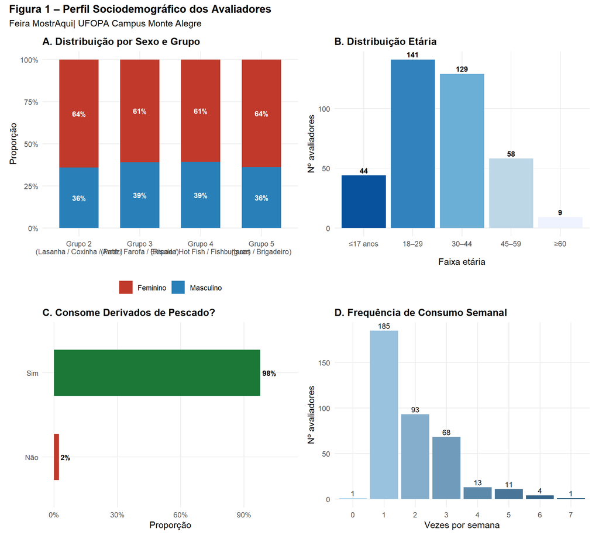

Figura 1 – Perfil Sociodemográfico dos Avaliadores

```r
df_perfil <- df %>% distinct(grupo, grupo_label, entrevistado, .keep_all = TRUE)

p1a <- df_perfil %>%
  filter(!is.na(sexo)) %>%
  count(grupo_label, sexo) %>%
  group_by(grupo_label) %>%
  mutate(pct = n / sum(n)) %>%
  ggplot(aes(grupo_label, pct, fill = sexo)) +
  geom_col(width = 0.65) +
  geom_text(aes(label = percent(pct, accuracy = 1)),
            position = position_stack(vjust = 0.5),
            size = 3.2, color = "white", fontface = "bold") +
  scale_fill_manual(values = c(Feminino = COR_NEG, Masculino = "#2980B9")) +
  scale_y_continuous(labels = percent_format()) +
  labs(title = "A. Distribuição por Sexo e Grupo", x = NULL, y = "Proporção", fill = NULL) +
  tema_mostraqui

p1b <- df_perfil %>%
  filter(!is.na(faixa_etaria)) %>%
  count(faixa_etaria) %>%
  ggplot(aes(faixa_etaria, n, fill = faixa_etaria)) +
  geom_col(show.legend = FALSE) +
  geom_text(aes(label = n), vjust = -0.4, size = 3.2, fontface = "bold") +
  scale_fill_brewer(palette = "Blues", direction = -1) +
  labs(title = "B. Distribuição Etária", x = "Faixa etária", y = "Nº avaliadores") +
  tema_mostraqui

p1c <- df_perfil %>%
  filter(!is.na(derivados)) %>%
  count(derivados) %>%
  mutate(pct = n / sum(n)) %>%
  ggplot(aes(reorder(derivados, pct), pct, fill = derivados)) +
  geom_col(show.legend = FALSE, width = 0.55) +
  geom_text(aes(label = percent(pct, accuracy = 1)),
            hjust = -0.15, size = 3.2, fontface = "bold") +
  coord_flip() +
  scale_fill_manual(values = c(Sim = COR_POS, Não = COR_NEG)) +
  scale_y_continuous(labels = percent_format(), limits = c(0, 1.1)) +
  labs(title = "C. Consome Derivados de Pescado?", x = NULL, y = "Proporção") +
  tema_mostraqui

p1d <- df_perfil %>%
  filter(!is.na(vezes)) %>%
  count(vezes) %>%
  mutate(vezes_f = factor(vezes)) %>%
  ggplot(aes(vezes_f, n, fill = vezes)) +
  geom_col(show.legend = FALSE) +
  geom_text(aes(label = n), vjust = -0.4, size = 3) +
  scale_fill_gradient(low = "#AED6F1", high = "#1A5276") +
  labs(title = "D. Frequência de Consumo Semanal",
       x = "Vezes por semana", y = "Nº avaliadores") +
  tema_mostraqui

(p1a | p1b) / (p1c | p1d) +
  plot_annotation(
    title    = "Figura 1 – Perfil Sociodemográfico dos Avaliadores",
    subtitle = "Feira MostrAqui| UFOPA Campus Monte Alegre",
    theme    = theme(plot.title = element_text(face = "bold", size = 13))
  )
```

> **Interpretação:** O painel A revela a predominância feminina em todos os grupos (≈ 61–64%). O painel B mostra concentração de avaliadores jovens (18–29 anos). O painel C confirma que quase a totalidade dos avaliadores (> 94%) consome derivados de pescado, garantindo familiaridade com o produto avaliado. O painel D informa a frequência habitual de consumo essencial para contextualizar o nível de exigência do painel.

## 13.3 Figura 2 – Mapa de Calor

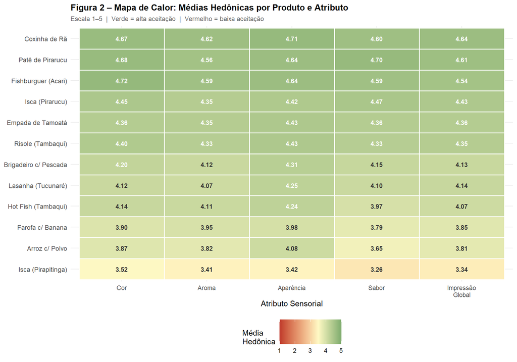

Figura 2 – Mapa de Calor: Médias Hedônicas por Produto e Atributo

```r
heat_long <- resumo_prod %>%
  dplyr::select(produto_abrev, Cor, Aroma, Aparencia, Sabor, Impressao) %>%
  pivot_longer(-produto_abrev, names_to = "Atributo", values_to = "Media") %>%
  mutate(Atributo = factor(Atributo,
                           levels = c("Cor","Aroma","Aparencia","Sabor","Impressao"),
                           labels = c("Cor","Aroma","Aparência","Sabor","Impressão\nGlobal")))

ggplot(heat_long,
       aes(Atributo, reorder(produto_abrev, Media), fill = Media)) +
  geom_tile(color = "white", linewidth = 0.6) +
  geom_text(aes(label = sprintf("%.2f", Media)),
            size = 3, fontface = "bold",
            color = ifelse(heat_long$Media >= 4.2, "white", "grey20")) +
  scale_fill_gradient2(
    low = COR_NEG, mid = "#FFF9C4", high = COR_POS,
    midpoint = 3.5, limits = c(1, 5), name = "Média\nHedônica"
  ) +
  labs(
    title    = "Figura 2 – Mapa de Calor: Médias Hedônicas por Produto e Atributo",
    subtitle = "Escala 1–5  |  Verde = alta aceitação  |  Vermelho = baixa aceitação",
    x = "Atributo Sensorial", y = NULL
  ) +
  tema_mostraqui +
  theme(axis.text.y = element_text(size = 9),
        legend.key.height = unit(1.2, "cm"))
```

## 13.4 Figura 3 – Boxplot da Impressão Global

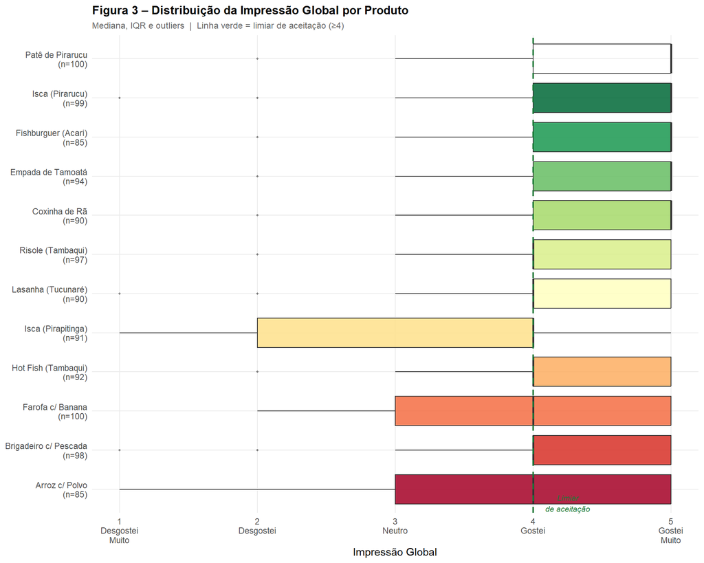

Figura 3 – Distribuição da Impressão Global por Produto

```r
n_obs <- df %>% filter(!is.na(impressao)) %>%
  count(produto_abrev) %>% rename(n_label = n)

df %>%
  filter(!is.na(impressao)) %>%
  left_join(n_obs, by = "produto_abrev") %>%
  mutate(prod_n = paste0(produto_abrev, "\n(n=", n_label, ")")) %>%
  ggplot(aes(reorder(prod_n, impressao, FUN = median), impressao,
             fill = reorder(prod_n, impressao, FUN = median))) +
  geom_boxplot(outlier.size = 0.7, alpha = 0.85, show.legend = FALSE,
               outlier.color = "grey50") +
  geom_hline(yintercept = 4, linetype = "dashed",
             color = COR_POS, linewidth = 0.8) +
  annotate("text", x = 0.65, y = 4.25, label = "Limiar\nde aceitação",
           size = 2.8, color = COR_POS, fontface = "italic") +
  scale_fill_brewer(palette = "RdYlGn", direction = 1) +
  scale_y_continuous(
    breaks = 1:5,
    labels = c("1\nDesgostei\nMuito","2\nDesgostei",
               "3\nNeutro","4\nGostei","5\nGostei\nMuito")
  ) +
  coord_flip() +
  labs(
    title    = "Figura 3 – Distribuição da Impressão Global por Produto",
    subtitle = "Mediana, IQR e outliers  |  Linha verde = limiar de aceitação (≥4)",
    x = NULL, y = "Impressão Global"
  ) +
  tema_mostraqui
```

## 13.5 Figura 4 – Frequência Hedônica Empilhada

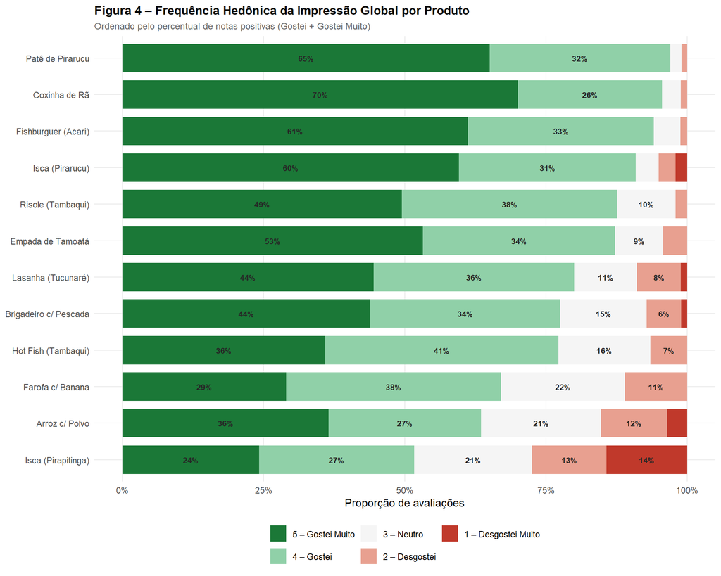

Figura 4 – Frequência Hedônica da Impressão Global por Produto

```r
df_hed <- df %>%
  filter(!is.na(impressao)) %>%
  mutate(nota_cat = factor(impressao, levels = 1:5,
                           labels = c("1 – Desgostei Muito","2 – Desgostei",
                                      "3 – Neutro","4 – Gostei","5 – Gostei Muito"),
                           ordered = TRUE))

hed_freq <- df_hed %>%
  count(produto_abrev, nota_cat) %>%
  group_by(produto_abrev) %>%
  mutate(pct = n / sum(n))

ordem_aceito <- hed_freq %>%
  filter(nota_cat %in% c("4 – Gostei","5 – Gostei Muito")) %>%
  group_by(produto_abrev) %>%
  summarise(pct_pos = sum(pct)) %>%
  arrange(pct_pos) %>% pull(produto_abrev)

cores_hed5 <- c(
  "1 – Desgostei Muito" = COR_NEG,
  "2 – Desgostei"       = "#E8A090",
  "3 – Neutro"          = "#F5F5F5",
  "4 – Gostei"          = "#90D0A8",
  "5 – Gostei Muito"    = COR_POS
)

hed_freq %>%
  mutate(produto_abrev = factor(produto_abrev, levels = ordem_aceito)) %>%
  ggplot(aes(produto_abrev, pct, fill = nota_cat)) +
  geom_col(position = "stack", width = 0.78) +
  geom_text(
    aes(label = ifelse(pct >= 0.06, percent(pct, accuracy = 1), "")),
    position = position_stack(vjust = 0.5),
    size = 2.8, color = "grey15", fontface = "bold"
  ) +
  coord_flip() +
  scale_fill_manual(values = cores_hed5, name = NULL) +
  scale_y_continuous(labels = percent_format()) +
  labs(
    title    = "Figura 4 – Frequência Hedônica da Impressão Global por Produto",
    subtitle = "Ordenado pelo percentual de notas positivas (Gostei + Gostei Muito)",
    x = NULL, y = "Proporção de avaliações"
  ) +
  guides(fill = guide_legend(reverse = TRUE, nrow = 2)) +
  tema_mostraqui
```

> **Interpretação:** Quanto maior a proporção de verde escuro (“5 – Gostei Muito”) e verde claro (“4 – Gostei”), melhor o produto. Produtos no topo do gráfico concentram quase toda a barra nas categorias positivas. Observe a Isca de Pirapitinga no fundo, com proporção expressiva de vermelho sinal inequívoco de rejeição.

## 13.6 Figura 5 – Índice de Aceitabilidade

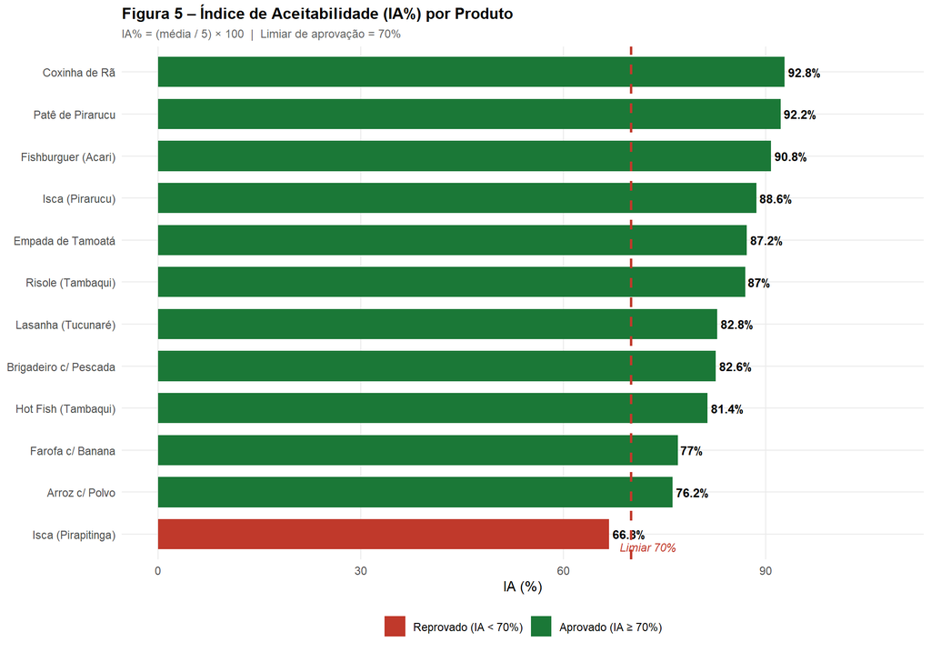

Figura 5 – Índice de Aceitabilidade (IA%) por Produto

```r
ia_tab %>%
  ggplot(aes(reorder(produto_abrev, IA_impressao), IA_impressao,
             fill = IA_impressao >= 70)) +
  geom_col(width = 0.72) +
  geom_text(aes(label = paste0(IA_impressao, "%")),
            hjust = -0.1, size = 3.3, fontface = "bold") +
  geom_hline(yintercept = 70, linetype = "dashed",
             color = COR_NEG, linewidth = 0.9) +
  annotate("text", x = 0.7, y = 72.5,
           label = "Limiar 70%", color = COR_NEG, size = 3, fontface = "italic") +
  coord_flip() +
  scale_fill_manual(
    values = c("TRUE" = COR_POS, "FALSE" = COR_NEG),
    labels = c("TRUE" = "Aprovado (IA ≥ 70%)", "FALSE" = "Reprovado (IA < 70%)"),
    name   = NULL
  ) +
  scale_y_continuous(limits = c(0, 108)) +
  labs(
    title    = "Figura 5 – Índice de Aceitabilidade (IA%) por Produto",
    subtitle = "IA% = (média / 5) × 100  |  Limiar de aprovação = 70%",
    x = NULL, y = "IA (%)"
  ) +
  tema_mostraqui
```

> **Interpretação:** A distância de cada barra ao limiar de 70% representa a “margem de segurança” do produto. Produtos com IA > 85% têm aprovação sólida; entre 70–80% são aprovados, mas merecem atenção em formulação ou apresentação. O único produto reprovado (Isca de Pirapitinga, IA = 66,8%) está marginalmente abaixo do limiar, indicando que reformulações pontuais podem ser suficientes para aprovação.

## 13.7 Figura 6 – Intenção de Compra

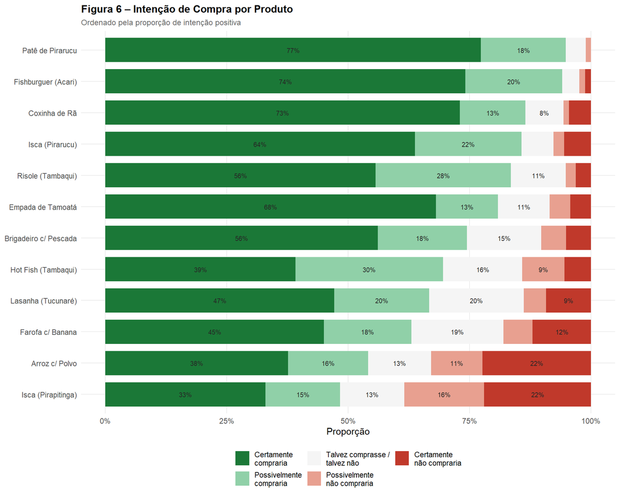

Figura 6 – Intenção de Compra por Produto

```r
compra_freq <- df %>%
  filter(!is.na(compra_ord)) %>%
  count(produto_abrev, compra_ord) %>%
  group_by(produto_abrev) %>%
  mutate(pct = n / sum(n))

ordem_compra <- compra_freq %>%
  filter(compra_ord %in% c("Possivelmente\ncompraria","Certamente\ncompraria")) %>%
  group_by(produto_abrev) %>%
  summarise(pct_pos = sum(pct)) %>%
  arrange(pct_pos) %>% pull(produto_abrev)

cores_compra <- c(
  "Certamente\nnão compraria"      = COR_NEG,
  "Possivelmente\nnão compraria"   = "#E8A090",
  "Talvez comprasse /\ntalvez não" = "#F5F5F5",
  "Possivelmente\ncompraria"       = "#90D0A8",
  "Certamente\ncompraria"          = COR_POS
)

compra_freq %>%
  mutate(produto_abrev = factor(produto_abrev, levels = ordem_compra)) %>%
  ggplot(aes(produto_abrev, pct, fill = compra_ord)) +
  geom_col(position = "stack", width = 0.78) +
  geom_text(
    aes(label = ifelse(pct >= 0.07, percent(pct, accuracy = 1), "")),
    position = position_stack(vjust = 0.5),
    size = 2.7, color = "grey15"
  ) +
  coord_flip() +
  scale_fill_manual(values = cores_compra, name = NULL) +
  scale_y_continuous(labels = percent_format()) +
  labs(
    title    = "Figura 6 – Intenção de Compra por Produto",
    subtitle = "Ordenado pela proporção de intenção positiva",
    x = NULL, y = "Proporção"
  ) +
  guides(fill = guide_legend(reverse = TRUE, nrow = 2)) +
  tema_mostraqui
```

> **Interpretação:** A intenção de compra é um indicador de viabilidade comercial. Produtos com > 80% de intenção positiva (verde) têm forte potencial de mercado. Contraste com a aceitação hedônica: um produto pode ser “gostado” (IA alto) mas não necessariamente comprado (preço percebido, familiaridade, disponibilidade), tornando a intenção de compra um indicador complementar e mais conservador.

## 13.8 Figura 7 – Médias por Atributo e Grupo

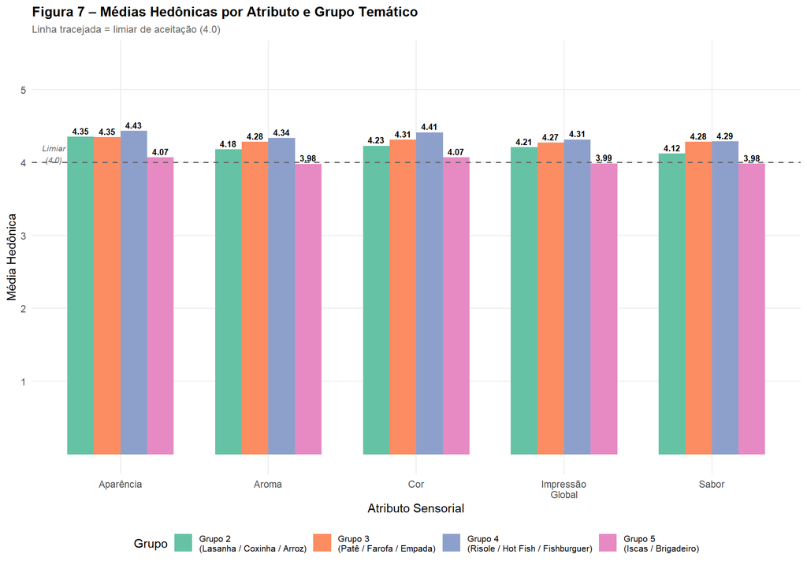

Figura 7 – Médias Hedônicas por Atributo e Grupo Temático

```r
grupo_long <- df %>%
  group_by(grupo_label) %>%
  summarise(
    Cor               = mean(cor,       na.rm = TRUE),
    Aroma             = mean(aroma,     na.rm = TRUE),
    Aparência         = mean(aparencia, na.rm = TRUE),
    Sabor             = mean(sabor,     na.rm = TRUE),
    `Impressão\nGlobal` = mean(impressao, na.rm = TRUE),
    .groups = "drop"
  ) %>%
  pivot_longer(-grupo_label, names_to = "Atributo", values_to = "Media")

ggplot(grupo_long, aes(Atributo, Media, fill = grupo_label)) +
  geom_col(position = "dodge", width = 0.72) +
  geom_hline(yintercept = 4, linetype = "dashed",
             color = "grey40", linewidth = 0.7) +
  geom_text(aes(label = sprintf("%.2f", Media)),
            position = position_dodge(0.72), vjust = -0.4,
            size = 2.7, fontface = "bold") +
  annotate("text", x = 0.55, y = 4.12, label = "Limiar\n(4.0)",
           size = 2.5, color = "grey40", fontface = "italic") +
  scale_fill_brewer(palette = "Set2", name = "Grupo") +
  scale_y_continuous(limits = c(0, 5.4), breaks = 1:5) +
  labs(
    title    = "Figura 7 – Médias Hedônicas por Atributo e Grupo Temático",
    subtitle = "Linha tracejada = limiar de aceitação (4.0)",
    x = "Atributo Sensorial", y = "Média Hedônica"
  ) +
  tema_mostraqui +
  theme(legend.text = element_text(size = 8))
```

> **Interpretação:** Este gráfico permite comparar o **perfil de forças e fraquezas** de cada grupo. Se um grupo tem excelente aparência mas sabor abaixo do limiar (< 4,0), há oportunidade de melhoria na formulação gustativa. Grupos com todas as barras acima de 4,0 demonstram consistência hedônica em todos os atributos avaliados.

## 13.9 Figura 8 – Correlações de Spearman

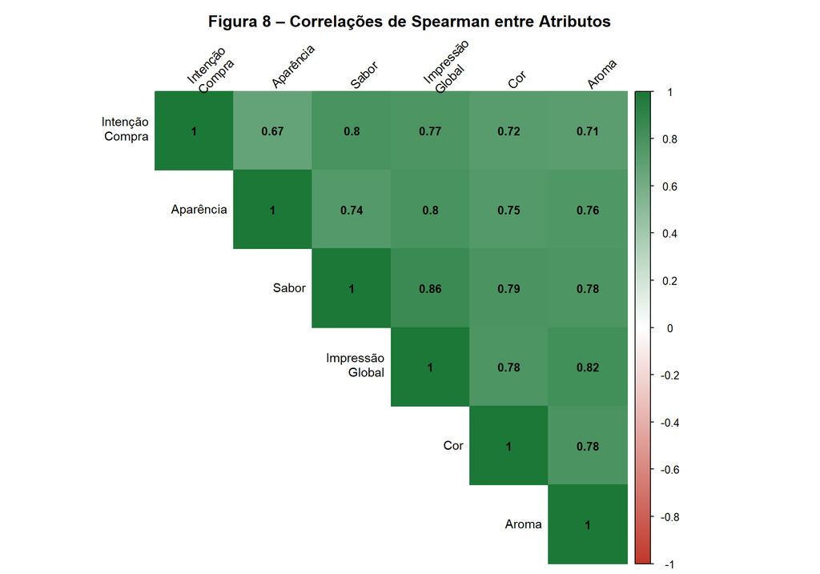

Figura 8 – Correlações de Spearman entre Atributos

```r
cor_mat_fig <- cor_mat
colnames(cor_mat_fig) <- rownames(cor_mat_fig) <-
  c("Cor","Aroma","Aparência","Sabor","Impressão\nGlobal","Intenção\nCompra")

corrplot(cor_mat_fig,
         method      = "color",
         type        = "upper",
         order       = "hclust",
         addCoef.col = "black",
         tl.col      = "black",
         tl.srt      = 45,
         col         = colorRampPalette(c(COR_NEG, "white", COR_POS))(200),
         title       = "Figura 8 – Correlações de Spearman entre Atributos",
         mar         = c(0, 0, 2.5, 0),
         number.cex  = 0.85,
         tl.cex      = 0.9)
```

> **Interpretação:** Células verde-escuras indicam correlação alta e positiva (ρ próximo de 1). O agrupamento hierárquico (ordem `hclust`) agrupa atributos com comportamento semelhante. Correlações altas entre **sabor, impressão e compra** confirmam que o sabor é o motor da aceitação e da intenção de compra neste estudo.

## 13.10 Figura 9 – Biplot ACP

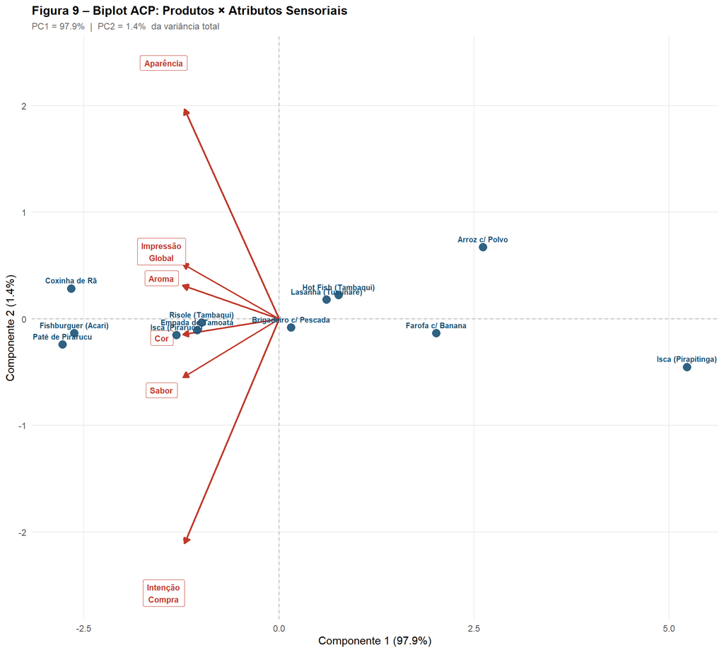

Figura 9 – Biplot ACP: Produtos × Atributos Sensoriais

```r
scores_df   <- as.data.frame(pca_res$x[, 1:2]) %>%
  rownames_to_column("produto")
loadings_df <- as.data.frame(pca_res$rotation[, 1:2]) %>%
  rownames_to_column("variavel") %>%
  mutate(variavel = recode(variavel,
                           Cor       = "Cor",
                           Aroma     = "Aroma",
                           Aparencia = "Aparência",
                           Sabor     = "Sabor",
                           Impressao = "Impressão\nGlobal",
                           Compra    = "Intenção\nCompra"))

escala_load <- 3.0

ggplot() +
  geom_hline(yintercept = 0, linetype = "dashed", color = "grey70") +
  geom_vline(xintercept = 0, linetype = "dashed", color = "grey70") +
  geom_segment(data = loadings_df,
               aes(x = 0, y = 0,
                   xend = PC1 * escala_load,
                   yend = PC2 * escala_load),
               arrow = arrow(length = unit(0.22, "cm"), type = "closed"),
               color = COR_NEG, linewidth = 0.85) +
  geom_label(data = loadings_df,
             aes(x = PC1 * escala_load * 1.22,
                 y = PC2 * escala_load * 1.22,
                 label = variavel),
             color = COR_NEG, size = 2.9, fontface = "bold",
             fill = "white", label.size = 0.15,
             label.padding = unit(0.15, "cm")) +
  geom_point(data = scores_df, aes(PC1, PC2),
             color = "#1A5276", size = 3.5, alpha = 0.9) +
  geom_text(data = scores_df, aes(PC1, PC2, label = produto),
            vjust = -0.9, size = 2.6, color = "#1A5276", fontface = "bold") +
  labs(
    title    = "Figura 9 – Biplot ACP: Produtos × Atributos Sensoriais",
    subtitle = sprintf("PC1 = %.1f%%  |  PC2 = %.1f%%  da variância total",
                       var_exp[1], var_exp[2]),
    x = sprintf("Componente 1 (%.1f%%)", var_exp[1]),
    y = sprintf("Componente 2 (%.1f%%)", var_exp[2])
  ) +
  tema_mostraqui
```

> **Interpretação:** **Setas vermelhas** = atributos sensoriais; **pontos azuis** = produtos. Produtos posicionados na mesma direção de uma seta têm alto desempenho naquele atributo. Produtos próximos entre si têm perfil sensorial similar. Produtos opostos ao longo do PC1 representam os extremos de aceitação (melhor vs. pior avaliados). Use o biplot para identificar quais atributos **diferenciam** os produtos de topo dos de base.

## 13.11 Figura 10 – Impressão Global por Sexo

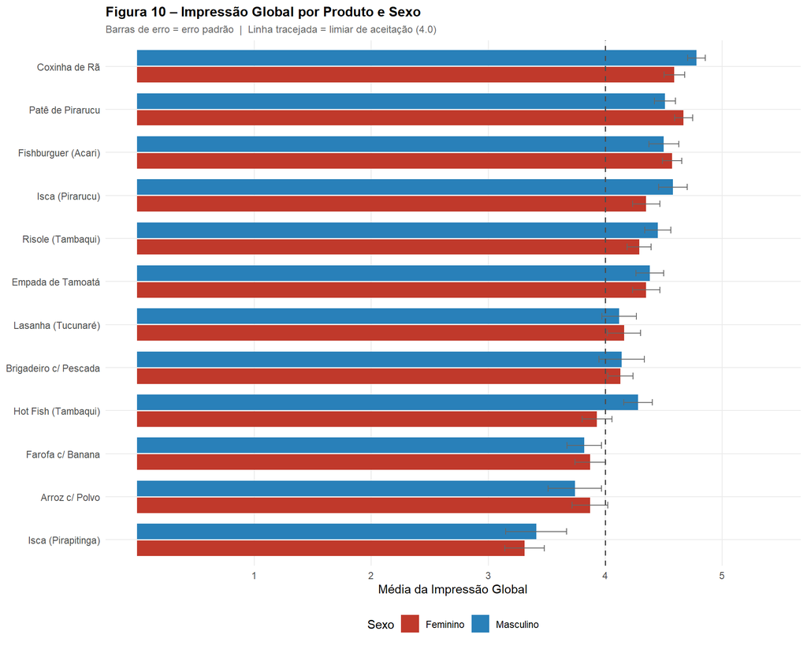

Figura 10 – Impressão Global por Produto e Sexo

```r
df_sx_prod <- df %>%
  filter(sexo %in% c("Feminino","Masculino"), !is.na(impressao)) %>%
  group_by(produto_abrev, sexo) %>%
  summarise(media = round(mean(impressao), 2),
            ep    = sd(impressao, na.rm = TRUE) / sqrt(n()),
            .groups = "drop")

df_sx_prod %>%
  ggplot(aes(reorder(produto_abrev, media), media, fill = sexo)) +
  geom_col(position = position_dodge(0.78), width = 0.72) +
  geom_errorbar(aes(ymin = media - ep, ymax = media + ep),
                position = position_dodge(0.78), width = 0.3,
                linewidth = 0.5, color = "grey40") +
  geom_hline(yintercept = 4, linetype = "dashed",
             color = "grey30", linewidth = 0.7) +
  coord_flip() +
  scale_fill_manual(values = c(Feminino = COR_NEG, Masculino = "#2980B9")) +
  scale_y_continuous(limits = c(0, 5.4), breaks = 1:5) +
  labs(
    title    = "Figura 10 – Impressão Global por Produto e Sexo",
    subtitle = "Barras de erro = erro padrão  |  Linha tracejada = limiar de aceitação (4.0)",
    x = NULL, y = "Média da Impressão Global", fill = "Sexo"
  ) +
  tema_mostraqui
```

> **Interpretação:** Barras de cores próximas e sobrepostas nas barras de erro indicam que homens e mulheres avaliam o produto de forma semelhante ausência de viés de gênero. Quando as barras divergem substancialmente (sem sobreposição dos erros padrão), o produto tem apelo diferenciado por sexo, o que deve orientar estratégias de posicionamento. A linha tracejada facilita identificar quais grupos (sexo × produto) atingem o limiar de aceitação.

# 14 Resumo conclusivo

> **Conclusão Geral:**  
> A Feira MostrAqui demonstrou com sucesso a viabilidade sensorial e comercial de produtos derivados de pescado. Com **91,7% de aprovação** pelo Índice de Aceitabilidade e médias hedônicas acima de 4,0 na maioria dos produtos, o evento evidencia o potencial gastronômico e econômico das espécies regionais como tucunaré, tambaqui, pirarucu, rã e polvo. As formulações líderes Patê de Pirarucu, Coxinha de Rã e Fishburguer de Acari reúnem altos índices de aceitação e intenção de compra, indicando prontidão para escalonamento comercial. A única exceção, a Isca de Pirapitinga, deve ser revisada em seu perfil de sabor antes de nova avaliação.

*Documento elaborado na linguagem de programação R por meio do framework R Markdown. Para a reprodução integral das análises, recomenda-se que o arquivo `df_mostraqui.xlsx` esteja no diretório de trabalho e que todos os pacotes descritos na Seção 1 estejam devidamente instalados no ambiente computacional. O cientista de dados Dr. Carlos Antônio Zarzar agradece sua leitura completa até aqui.*